```python
import pandas as pd
from IPython.core.display import display, HTML
import seaborn as sns
import matplotlib.pyplot as plt
import numpy as np
%matplotlib inline
```

# Read files

```python
# stations
station = pd.read_csv('data/station.csv')
display(station.describe())
display(station.dtypes)
display(station.head(n=10))
```

|  | lat | long | install_dockcount | current_dockcount |
| --- | --- | --- | --- | --- |
| count | 58.000000 | 58.000000 | 58.000000 | 58.000000 |
| mean | 47.624796 | -122.327242 | 17.586207 | 16.517241 |
| std | 0.019066 | 0.014957 | 3.060985 | 5.117021 |
| min | 47.598488 | -122.355230 | 12.000000 | 0.000000 |
| 25% | 47.613239 | -122.338735 | 16.000000 | 16.000000 |
| 50% | 47.618591 | -122.328207 | 18.000000 | 18.000000 |
| 75% | 47.627712 | -122.316691 | 18.000000 | 18.000000 |
| max | 47.666145 | -122.284119 | 30.000000 | 26.000000 |

```
station_id            object
name                  object
lat                  float64
long                 float64
install_date          object
install_dockcount      int64
modification_date     object
current_dockcount      int64
decommission_date     object
dtype: object
```

|  | station_id | name | lat | long | install_date | install_dockcount | modification_date | current_dockcount | decommission_date |
| --- | --- | --- | --- | --- | --- | --- | --- | --- | --- |
| 0 | BT-01 | 3rd Ave & Broad St | 47.618418 | -122.350964 | 10/13/2014 | 18 | NaN | 18 | NaN |
| 1 | BT-03 | 2nd Ave & Vine St | 47.615829 | -122.348564 | 10/13/2014 | 16 | NaN | 16 | NaN |
| 2 | BT-04 | 6th Ave & Blanchard St | 47.616094 | -122.341102 | 10/13/2014 | 16 | NaN | 16 | NaN |
| 3 | BT-05 | 2nd Ave & Blanchard St | 47.613110 | -122.344208 | 10/13/2014 | 14 | NaN | 14 | NaN |
| 4 | CBD-03 | 7th Ave & Union St | 47.610731 | -122.332447 | 10/13/2014 | 20 | NaN | 20 | NaN |
| 5 | CBD-04 | Union St & 4th Ave | 47.609221 | -122.335596 | 7/27/2015 | 18 | NaN | 18 | NaN |
| 6 | CBD-05 | 1st Ave & Marion St | 47.604058 | -122.335800 | 10/13/2014 | 20 | NaN | 20 | NaN |
| 7 | CBD-06 | 2nd Ave & Spring St | 47.605950 | -122.335768 | 10/13/2014 | 20 | 11/9/2015 | 18 | NaN |
| 8 | CBD-07 | City Hall / 4th Ave & James St | 47.603509 | -122.330409 | 10/13/2014 | 20 | NaN | 20 | NaN |
| 9 | CBD-13 | 2nd Ave & Pine St | 47.610185 | -122.339641 | 10/13/2014 | 18 | NaN | 18 | NaN |

```python
# yes, we found a bad line 50794, but we can solve it using error_bad_lines
trips = pd.read_csv('data/trip.csv', error_bad_lines=False, warn_bad_lines=True, parse_dates=['starttime', 'stoptime'] )
display(trips.describe())
display(trips.dtypes)
display(trips.head(n=10))
# check if there are duplicate id's, i.e. if
print(len(trips.groupby('trip_id')['trip_id'].nunique()), len(trips))
# since we have duplicate values
trips = trips.drop_duplicates(['trip_id'], keep='first', inplace=False)
display(trips.describe())
display(trips.dtypes)
display(trips.head(n=10))
```

```
b'Skipping line 50794: expected 12 fields, saw 20\n'
```

|  | trip_id | tripduration | birthyear |
| --- | --- | --- | --- |
| count | 286857.000000 | 286857.000000 | 181553.000000 |
| mean | 112431.968012 | 1178.295675 | 1979.759062 |
| std | 76565.154943 | 2038.458947 | 10.167119 |
| min | 431.000000 | 60.008000 | 1931.000000 |
| 25% | 43051.000000 | 387.924000 | 1974.000000 |
| 50% | 103487.000000 | 624.842000 | 1983.000000 |
| 75% | 179545.000000 | 1118.466000 | 1987.000000 |
| max | 255245.000000 | 28794.398000 | 1999.000000 |

```
trip_id                       int64
starttime            datetime64[ns]
stoptime             datetime64[ns]
bikeid                       object
tripduration                float64
from_station_name            object
to_station_name              object
from_station_id              object
to_station_id                object
usertype                     object
gender                       object
birthyear                   float64
dtype: object
```

|  | trip_id | starttime | stoptime | bikeid | tripduration | from_station_name | to_station_name | from_station_id | to_station_id | usertype | gender | birthyear |
| --- | --- | --- | --- | --- | --- | --- | --- | --- | --- | --- | --- | --- |
| 0 | 431 | 2014-10-13 10:31:00 | 2014-10-13 10:48:00 | SEA00298 | 985.935 | 2nd Ave & Spring St | Occidental Park / Occidental Ave S & S Washing... | CBD-06 | PS-04 | Member | Male | 1960.0 |
| 1 | 432 | 2014-10-13 10:32:00 | 2014-10-13 10:48:00 | SEA00195 | 926.375 | 2nd Ave & Spring St | Occidental Park / Occidental Ave S & S Washing... | CBD-06 | PS-04 | Member | Male | 1970.0 |
| 2 | 433 | 2014-10-13 10:33:00 | 2014-10-13 10:48:00 | SEA00486 | 883.831 | 2nd Ave & Spring St | Occidental Park / Occidental Ave S & S Washing... | CBD-06 | PS-04 | Member | Female | 1988.0 |
| 3 | 434 | 2014-10-13 10:34:00 | 2014-10-13 10:48:00 | SEA00333 | 865.937 | 2nd Ave & Spring St | Occidental Park / Occidental Ave S & S Washing... | CBD-06 | PS-04 | Member | Female | 1977.0 |
| 4 | 435 | 2014-10-13 10:34:00 | 2014-10-13 10:49:00 | SEA00202 | 923.923 | 2nd Ave & Spring St | Occidental Park / Occidental Ave S & S Washing... | CBD-06 | PS-04 | Member | Male | 1971.0 |
| 5 | 436 | 2014-10-13 10:34:00 | 2014-10-13 10:47:00 | SEA00337 | 808.805 | 2nd Ave & Spring St | Occidental Park / Occidental Ave S & S Washing... | CBD-06 | PS-04 | Member | Male | 1974.0 |
| 6 | 437 | 2014-10-13 11:35:00 | 2014-10-13 11:45:00 | SEA00202 | 596.715 | Occidental Park / Occidental Ave S & S Washing... | King Street Station Plaza / 2nd Ave Extension ... | PS-04 | PS-05 | Member | Male | 1978.0 |
| 7 | 438 | 2014-10-13 11:35:00 | 2014-10-13 11:45:00 | SEA00311 | 592.131 | Occidental Park / Occidental Ave S & S Washing... | King Street Station Plaza / 2nd Ave Extension ... | PS-04 | PS-05 | Member | Male | 1983.0 |
| 8 | 439 | 2014-10-13 11:35:00 | 2014-10-13 11:45:00 | SEA00486 | 586.347 | Occidental Park / Occidental Ave S & S Washing... | King Street Station Plaza / 2nd Ave Extension ... | PS-04 | PS-05 | Member | Female | 1974.0 |
| 9 | 440 | 2014-10-13 11:35:00 | 2014-10-13 11:45:00 | SEA00434 | 587.634 | Occidental Park / Occidental Ave S & S Washing... | King Street Station Plaza / 2nd Ave Extension ... | PS-04 | PS-05 | Member | Male | 1958.0 |

```
236065 286857
```

|  | trip_id | tripduration | birthyear |
| --- | --- | --- | --- |
| count | 236065.000000 | 236065.00000 | 146167.000000 |
| mean | 130059.869333 | 1202.61221 | 1979.879740 |
| std | 72842.289278 | 2066.42488 | 10.154978 |
| min | 431.000000 | 60.00800 | 1931.000000 |
| 25% | 67746.000000 | 392.26500 | 1975.000000 |
| 50% | 130526.000000 | 633.23500 | 1983.000000 |
| 75% | 192900.000000 | 1145.01500 | 1987.000000 |
| max | 255245.000000 | 28794.39800 | 1999.000000 |

```
trip_id                       int64
starttime            datetime64[ns]
stoptime             datetime64[ns]
bikeid                       object
tripduration                float64
from_station_name            object
to_station_name              object
from_station_id              object
to_station_id                object
usertype                     object
gender                       object
birthyear                   float64
dtype: object
```

|  | trip_id | starttime | stoptime | bikeid | tripduration | from_station_name | to_station_name | from_station_id | to_station_id | usertype | gender | birthyear |
| --- | --- | --- | --- | --- | --- | --- | --- | --- | --- | --- | --- | --- |
| 0 | 431 | 2014-10-13 10:31:00 | 2014-10-13 10:48:00 | SEA00298 | 985.935 | 2nd Ave & Spring St | Occidental Park / Occidental Ave S & S Washing... | CBD-06 | PS-04 | Member | Male | 1960.0 |
| 1 | 432 | 2014-10-13 10:32:00 | 2014-10-13 10:48:00 | SEA00195 | 926.375 | 2nd Ave & Spring St | Occidental Park / Occidental Ave S & S Washing... | CBD-06 | PS-04 | Member | Male | 1970.0 |
| 2 | 433 | 2014-10-13 10:33:00 | 2014-10-13 10:48:00 | SEA00486 | 883.831 | 2nd Ave & Spring St | Occidental Park / Occidental Ave S & S Washing... | CBD-06 | PS-04 | Member | Female | 1988.0 |
| 3 | 434 | 2014-10-13 10:34:00 | 2014-10-13 10:48:00 | SEA00333 | 865.937 | 2nd Ave & Spring St | Occidental Park / Occidental Ave S & S Washing... | CBD-06 | PS-04 | Member | Female | 1977.0 |
| 4 | 435 | 2014-10-13 10:34:00 | 2014-10-13 10:49:00 | SEA00202 | 923.923 | 2nd Ave & Spring St | Occidental Park / Occidental Ave S & S Washing... | CBD-06 | PS-04 | Member | Male | 1971.0 |
| 5 | 436 | 2014-10-13 10:34:00 | 2014-10-13 10:47:00 | SEA00337 | 808.805 | 2nd Ave & Spring St | Occidental Park / Occidental Ave S & S Washing... | CBD-06 | PS-04 | Member | Male | 1974.0 |
| 6 | 437 | 2014-10-13 11:35:00 | 2014-10-13 11:45:00 | SEA00202 | 596.715 | Occidental Park / Occidental Ave S & S Washing... | King Street Station Plaza / 2nd Ave Extension ... | PS-04 | PS-05 | Member | Male | 1978.0 |
| 7 | 438 | 2014-10-13 11:35:00 | 2014-10-13 11:45:00 | SEA00311 | 592.131 | Occidental Park / Occidental Ave S & S Washing... | King Street Station Plaza / 2nd Ave Extension ... | PS-04 | PS-05 | Member | Male | 1983.0 |
| 8 | 439 | 2014-10-13 11:35:00 | 2014-10-13 11:45:00 | SEA00486 | 586.347 | Occidental Park / Occidental Ave S & S Washing... | King Street Station Plaza / 2nd Ave Extension ... | PS-04 | PS-05 | Member | Female | 1974.0 |
| 9 | 440 | 2014-10-13 11:35:00 | 2014-10-13 11:45:00 | SEA00434 | 587.634 | Occidental Park / Occidental Ave S & S Washing... | King Street Station Plaza / 2nd Ave Extension ... | PS-04 | PS-05 | Member | Male | 1958.0 |

```python
# weather
weather = pd.read_csv('data/weather.csv', error_bad_lines=False, warn_bad_lines=True, parse_dates=['Date'])
display(weather.describe())
display(weather.dtypes)
display(weather.head(n=10))
```

|  | Max_Temperature_F | Mean_Temperature_F | Min_TemperatureF | Max_Dew_Point_F | MeanDew_Point_F | Min_Dewpoint_F | Max_Humidity | Mean_Humidity | Min_Humidity | Max_Sea_Level_Pressure_In | Mean_Sea_Level_Pressure_In | Min_Sea_Level_Pressure_In | Max_Visibility_Miles | Mean_Visibility_Miles | Min_Visibility_Miles | Max_Wind_Speed_MPH | Mean_Wind_Speed_MPH | Precipitation_In |
| --- | --- | --- | --- | --- | --- | --- | --- | --- | --- | --- | --- | --- | --- | --- | --- | --- | --- | --- |
| count | 689.000000 | 688.000000 | 689.000000 | 689.000000 | 689.000000 | 689.000000 | 689.000000 | 689.000000 | 689.000000 | 689.000000 | 689.000000 | 689.000000 | 689.000000 | 689.000000 | 689.000000 | 689.000000 | 689.00000 | 689.000000 |
| mean | 64.027576 | 56.584302 | 49.454282 | 48.571843 | 45.021771 | 40.873730 | 84.541364 | 68.506531 | 49.973875 | 30.121742 | 30.034761 | 29.940610 | 9.989840 | 9.429608 | 7.245283 | 11.085631 | 4.63135 | 0.105065 |
| std | 12.427843 | 10.408058 | 9.451437 | 7.501230 | 7.914025 | 8.854608 | 9.718948 | 12.701871 | 15.825701 | 0.183367 | 0.197503 | 0.221803 | 0.266679 | 1.174360 | 3.281278 | 3.921087 | 2.78032 | 0.235644 |
| min | 39.000000 | 33.000000 | 23.000000 | 10.000000 | 4.000000 | 1.000000 | 40.000000 | 24.000000 | 15.000000 | 29.470000 | 29.310000 | 29.140000 | 3.000000 | 1.000000 | 0.000000 | 4.000000 | 0.00000 | 0.000000 |
| 25% | 55.000000 | 48.000000 | 43.000000 | 44.000000 | 41.000000 | 36.000000 | 78.000000 | 60.000000 | 38.000000 | 30.010000 | 29.930000 | 29.840000 | 10.000000 | 9.000000 | 4.000000 | 8.000000 | 3.00000 | 0.000000 |
| 50% | 63.000000 | 56.000000 | 50.000000 | 50.000000 | 46.000000 | 42.000000 | 86.000000 | 70.000000 | 50.000000 | 30.120000 | 30.040000 | 29.960000 | 10.000000 | 10.000000 | 9.000000 | 10.000000 | 4.00000 | 0.000000 |
| 75% | 73.000000 | 65.000000 | 57.000000 | 54.000000 | 51.000000 | 47.000000 | 90.000000 | 79.000000 | 63.000000 | 30.240000 | 30.160000 | 30.080000 | 10.000000 | 10.000000 | 10.000000 | 13.000000 | 6.00000 | 0.090000 |
| max | 98.000000 | 83.000000 | 70.000000 | 77.000000 | 59.000000 | 57.000000 | 100.000000 | 95.000000 | 87.000000 | 30.860000 | 30.810000 | 30.750000 | 10.000000 | 10.000000 | 10.000000 | 30.000000 | 23.00000 | 2.200000 |

```
Date                          datetime64[ns]
Max_Temperature_F                      int64
Mean_Temperature_F                   float64
Min_TemperatureF                       int64
Max_Dew_Point_F                        int64
MeanDew_Point_F                        int64
Min_Dewpoint_F                         int64
Max_Humidity                           int64
Mean_Humidity                          int64
Min_Humidity                           int64
Max_Sea_Level_Pressure_In            float64
Mean_Sea_Level_Pressure_In           float64
Min_Sea_Level_Pressure_In            float64
Max_Visibility_Miles                   int64
Mean_Visibility_Miles                  int64
Min_Visibility_Miles                   int64
Max_Wind_Speed_MPH                     int64
Mean_Wind_Speed_MPH                    int64
Max_Gust_Speed_MPH                    object
Precipitation_In                     float64
Events                                object
dtype: object
```

|  | Date | Max_Temperature_F | Mean_Temperature_F | Min_TemperatureF | Max_Dew_Point_F | MeanDew_Point_F | Min_Dewpoint_F | Max_Humidity | Mean_Humidity | Min_Humidity | ... | Mean_Sea_Level_Pressure_In | Min_Sea_Level_Pressure_In | Max_Visibility_Miles | Mean_Visibility_Miles | Min_Visibility_Miles | Max_Wind_Speed_MPH | Mean_Wind_Speed_MPH | Max_Gust_Speed_MPH | Precipitation_In | Events |
| --- | --- | --- | --- | --- | --- | --- | --- | --- | --- | --- | --- | --- | --- | --- | --- | --- | --- | --- | --- | --- | --- |
| 0 | 2014-10-13 | 71 | 62.0 | 54 | 55 | 51 | 46 | 87 | 68 | 46 | ... | 29.79 | 29.65 | 10 | 10 | 4 | 13 | 4 | 21 | 0.00 | Rain |
| 1 | 2014-10-14 | 63 | 59.0 | 55 | 52 | 51 | 50 | 88 | 78 | 63 | ... | 29.75 | 29.54 | 10 | 9 | 3 | 10 | 5 | 17 | 0.11 | Rain |
| 2 | 2014-10-15 | 62 | 58.0 | 54 | 53 | 50 | 46 | 87 | 77 | 67 | ... | 29.71 | 29.51 | 10 | 9 | 3 | 18 | 7 | 25 | 0.45 | Rain |
| 3 | 2014-10-16 | 71 | 61.0 | 52 | 49 | 46 | 42 | 83 | 61 | 36 | ... | 29.95 | 29.81 | 10 | 10 | 10 | 9 | 4 | - | 0.00 | Rain |
| 4 | 2014-10-17 | 64 | 60.0 | 57 | 55 | 51 | 41 | 87 | 72 | 46 | ... | 29.78 | 29.73 | 10 | 10 | 6 | 8 | 3 | - | 0.14 | Rain |
| 5 | 2014-10-18 | 68 | 64.0 | 59 | 59 | 57 | 55 | 90 | 83 | 68 | ... | 29.90 | 29.80 | 10 | 8 | 2 | 10 | 4 | - | 0.31 | Rain |
| 6 | 2014-10-19 | 73 | 64.0 | 55 | 57 | 55 | 53 | 94 | 74 | 52 | ... | 29.73 | 29.67 | 10 | 10 | 6 | 10 | 3 | 18 | 0.00 | NaN |
| 7 | 2014-10-20 | 66 | 60.0 | 55 | 57 | 54 | 50 | 90 | 78 | 67 | ... | 29.74 | 29.69 | 10 | 10 | 5 | 12 | 5 | - | 0.44 | Rain |
| 8 | 2014-10-21 | 64 | 58.0 | 55 | 52 | 49 | 46 | 87 | 70 | 58 | ... | 29.85 | 29.74 | 10 | 10 | 6 | 15 | 8 | 21 | 0.10 | Rain |
| 9 | 2014-10-22 | 60 | 58.0 | 57 | 55 | 53 | 48 | 88 | 81 | 67 | ... | 29.68 | 29.56 | 10 | 6 | 2 | 14 | 8 | 22 | 1.43 | Rain |

10 rows × 21 columns

# Hipotesis

The goal is to predict demand bikes per stations. We presume, weather condictions will have a big impact on the demand. For this we need to plot total of rides with weather and try to see any impact. Then, we have a problem since we have a daily forecast and not an hourly forecast. We can try two approaches,

1. Trying to cluster the daily condictions
2. trying to get a hourly projection of the weather giving the data we have

```python
# Weather
weather['year'] = pd.DatetimeIndex(weather['Date']).year
weather['month'] = pd.DatetimeIndex(weather['Date']).month
weather['day'] = pd.DatetimeIndex(weather['Date']).day
display(weather.describe())
display(weather.dtypes)
display(weather.head(n=10))
```

|  | Max_Temperature_F | Mean_Temperature_F | Min_TemperatureF | Max_Dew_Point_F | MeanDew_Point_F | Min_Dewpoint_F | Max_Humidity | Mean_Humidity | Min_Humidity | Max_Sea_Level_Pressure_In | ... | Min_Sea_Level_Pressure_In | Max_Visibility_Miles | Mean_Visibility_Miles | Min_Visibility_Miles | Max_Wind_Speed_MPH | Mean_Wind_Speed_MPH | Precipitation_In | year | month | day |
| --- | --- | --- | --- | --- | --- | --- | --- | --- | --- | --- | --- | --- | --- | --- | --- | --- | --- | --- | --- | --- | --- |
| count | 689.000000 | 688.000000 | 689.000000 | 689.000000 | 689.000000 | 689.000000 | 689.000000 | 689.000000 | 689.000000 | 689.000000 | ... | 689.000000 | 689.000000 | 689.000000 | 689.000000 | 689.000000 | 689.00000 | 689.000000 | 689.000000 | 689.000000 | 689.000000 |
| mean | 64.027576 | 56.584302 | 49.454282 | 48.571843 | 45.021771 | 40.873730 | 84.541364 | 68.506531 | 49.973875 | 30.121742 | ... | 29.940610 | 9.989840 | 9.429608 | 7.245283 | 11.085631 | 4.63135 | 0.105065 | 2015.238026 | 6.351234 | 15.910015 |
| std | 12.427843 | 10.408058 | 9.451437 | 7.501230 | 7.914025 | 8.854608 | 9.718948 | 12.701871 | 15.825701 | 0.183367 | ... | 0.221803 | 0.266679 | 1.174360 | 3.281278 | 3.921087 | 2.78032 | 0.235644 | 0.643577 | 3.483558 | 8.795349 |
| min | 39.000000 | 33.000000 | 23.000000 | 10.000000 | 4.000000 | 1.000000 | 40.000000 | 24.000000 | 15.000000 | 29.470000 | ... | 29.140000 | 3.000000 | 1.000000 | 0.000000 | 4.000000 | 0.00000 | 0.000000 | 2014.000000 | 1.000000 | 1.000000 |
| 25% | 55.000000 | 48.000000 | 43.000000 | 44.000000 | 41.000000 | 36.000000 | 78.000000 | 60.000000 | 38.000000 | 30.010000 | ... | 29.840000 | 10.000000 | 9.000000 | 4.000000 | 8.000000 | 3.00000 | 0.000000 | 2015.000000 | 3.000000 | 8.000000 |
| 50% | 63.000000 | 56.000000 | 50.000000 | 50.000000 | 46.000000 | 42.000000 | 86.000000 | 70.000000 | 50.000000 | 30.120000 | ... | 29.960000 | 10.000000 | 10.000000 | 9.000000 | 10.000000 | 4.00000 | 0.000000 | 2015.000000 | 6.000000 | 16.000000 |
| 75% | 73.000000 | 65.000000 | 57.000000 | 54.000000 | 51.000000 | 47.000000 | 90.000000 | 79.000000 | 63.000000 | 30.240000 | ... | 30.080000 | 10.000000 | 10.000000 | 10.000000 | 13.000000 | 6.00000 | 0.090000 | 2016.000000 | 9.000000 | 23.000000 |
| max | 98.000000 | 83.000000 | 70.000000 | 77.000000 | 59.000000 | 57.000000 | 100.000000 | 95.000000 | 87.000000 | 30.860000 | ... | 30.750000 | 10.000000 | 10.000000 | 10.000000 | 30.000000 | 23.00000 | 2.200000 | 2016.000000 | 12.000000 | 31.000000 |

8 rows × 21 columns

```
Date                          datetime64[ns]
Max_Temperature_F                      int64
Mean_Temperature_F                   float64
Min_TemperatureF                       int64
Max_Dew_Point_F                        int64
MeanDew_Point_F                        int64
Min_Dewpoint_F                         int64
Max_Humidity                           int64
Mean_Humidity                          int64
Min_Humidity                           int64
Max_Sea_Level_Pressure_In            float64
Mean_Sea_Level_Pressure_In           float64
Min_Sea_Level_Pressure_In            float64
Max_Visibility_Miles                   int64
Mean_Visibility_Miles                  int64
Min_Visibility_Miles                   int64
Max_Wind_Speed_MPH                     int64
Mean_Wind_Speed_MPH                    int64
Max_Gust_Speed_MPH                    object
Precipitation_In                     float64
Events                                object
year                                   int64
month                                  int64
day                                    int64
dtype: object
```

|  | Date | Max_Temperature_F | Mean_Temperature_F | Min_TemperatureF | Max_Dew_Point_F | MeanDew_Point_F | Min_Dewpoint_F | Max_Humidity | Mean_Humidity | Min_Humidity | ... | Mean_Visibility_Miles | Min_Visibility_Miles | Max_Wind_Speed_MPH | Mean_Wind_Speed_MPH | Max_Gust_Speed_MPH | Precipitation_In | Events | year | month | day |
| --- | --- | --- | --- | --- | --- | --- | --- | --- | --- | --- | --- | --- | --- | --- | --- | --- | --- | --- | --- | --- | --- |
| 0 | 2014-10-13 | 71 | 62.0 | 54 | 55 | 51 | 46 | 87 | 68 | 46 | ... | 10 | 4 | 13 | 4 | 21 | 0.00 | Rain | 2014 | 10 | 13 |
| 1 | 2014-10-14 | 63 | 59.0 | 55 | 52 | 51 | 50 | 88 | 78 | 63 | ... | 9 | 3 | 10 | 5 | 17 | 0.11 | Rain | 2014 | 10 | 14 |
| 2 | 2014-10-15 | 62 | 58.0 | 54 | 53 | 50 | 46 | 87 | 77 | 67 | ... | 9 | 3 | 18 | 7 | 25 | 0.45 | Rain | 2014 | 10 | 15 |
| 3 | 2014-10-16 | 71 | 61.0 | 52 | 49 | 46 | 42 | 83 | 61 | 36 | ... | 10 | 10 | 9 | 4 | - | 0.00 | Rain | 2014 | 10 | 16 |
| 4 | 2014-10-17 | 64 | 60.0 | 57 | 55 | 51 | 41 | 87 | 72 | 46 | ... | 10 | 6 | 8 | 3 | - | 0.14 | Rain | 2014 | 10 | 17 |
| 5 | 2014-10-18 | 68 | 64.0 | 59 | 59 | 57 | 55 | 90 | 83 | 68 | ... | 8 | 2 | 10 | 4 | - | 0.31 | Rain | 2014 | 10 | 18 |
| 6 | 2014-10-19 | 73 | 64.0 | 55 | 57 | 55 | 53 | 94 | 74 | 52 | ... | 10 | 6 | 10 | 3 | 18 | 0.00 | NaN | 2014 | 10 | 19 |
| 7 | 2014-10-20 | 66 | 60.0 | 55 | 57 | 54 | 50 | 90 | 78 | 67 | ... | 10 | 5 | 12 | 5 | - | 0.44 | Rain | 2014 | 10 | 20 |
| 8 | 2014-10-21 | 64 | 58.0 | 55 | 52 | 49 | 46 | 87 | 70 | 58 | ... | 10 | 6 | 15 | 8 | 21 | 0.10 | Rain | 2014 | 10 | 21 |
| 9 | 2014-10-22 | 60 | 58.0 | 57 | 55 | 53 | 48 | 88 | 81 | 67 | ... | 6 | 2 | 14 | 8 | 22 | 1.43 | Rain | 2014 | 10 | 22 |

10 rows × 24 columns

```python
#calculate total trips per day
total_trips = (trips['starttime'].dt.date).to_frame(name='day')
total_trips = total_trips.groupby(['day'])['day'].count().reset_index(name='count')
total_trips['day'] = pd.to_datetime(total_trips['day'], format='%Y-%m-%d')

# and finally we join with the weather
weather = weather.join(total_trips.set_index('day'), on = 'Date')
display(weather.head(10))
```

|  | Date | Max_Temperature_F | Mean_Temperature_F | Min_TemperatureF | Max_Dew_Point_F | MeanDew_Point_F | Min_Dewpoint_F | Max_Humidity | Mean_Humidity | Min_Humidity | ... | Min_Visibility_Miles | Max_Wind_Speed_MPH | Mean_Wind_Speed_MPH | Max_Gust_Speed_MPH | Precipitation_In | Events | year | month | day | count |
| --- | --- | --- | --- | --- | --- | --- | --- | --- | --- | --- | --- | --- | --- | --- | --- | --- | --- | --- | --- | --- | --- |
| 0 | 2014-10-13 | 71 | 62.0 | 54 | 55 | 51 | 46 | 87 | 68 | 46 | ... | 4 | 13 | 4 | 21 | 0.00 | Rain | 2014 | 10 | 13 | 409 |
| 1 | 2014-10-14 | 63 | 59.0 | 55 | 52 | 51 | 50 | 88 | 78 | 63 | ... | 3 | 10 | 5 | 17 | 0.11 | Rain | 2014 | 10 | 14 | 491 |
| 2 | 2014-10-15 | 62 | 58.0 | 54 | 53 | 50 | 46 | 87 | 77 | 67 | ... | 3 | 18 | 7 | 25 | 0.45 | Rain | 2014 | 10 | 15 | 313 |
| 3 | 2014-10-16 | 71 | 61.0 | 52 | 49 | 46 | 42 | 83 | 61 | 36 | ... | 10 | 9 | 4 | - | 0.00 | Rain | 2014 | 10 | 16 | 395 |
| 4 | 2014-10-17 | 64 | 60.0 | 57 | 55 | 51 | 41 | 87 | 72 | 46 | ... | 6 | 8 | 3 | - | 0.14 | Rain | 2014 | 10 | 17 | 294 |
| 5 | 2014-10-18 | 68 | 64.0 | 59 | 59 | 57 | 55 | 90 | 83 | 68 | ... | 2 | 10 | 4 | - | 0.31 | Rain | 2014 | 10 | 18 | 399 |
| 6 | 2014-10-19 | 73 | 64.0 | 55 | 57 | 55 | 53 | 94 | 74 | 52 | ... | 6 | 10 | 3 | 18 | 0.00 | NaN | 2014 | 10 | 19 | 666 |
| 7 | 2014-10-20 | 66 | 60.0 | 55 | 57 | 54 | 50 | 90 | 78 | 67 | ... | 5 | 12 | 5 | - | 0.44 | Rain | 2014 | 10 | 20 | 389 |
| 8 | 2014-10-21 | 64 | 58.0 | 55 | 52 | 49 | 46 | 87 | 70 | 58 | ... | 6 | 15 | 8 | 21 | 0.10 | Rain | 2014 | 10 | 21 | 357 |
| 9 | 2014-10-22 | 60 | 58.0 | 57 | 55 | 53 | 48 | 88 | 81 | 67 | ... | 2 | 14 | 8 | 22 | 1.43 | Rain | 2014 | 10 | 22 | 141 |

10 rows × 25 columns

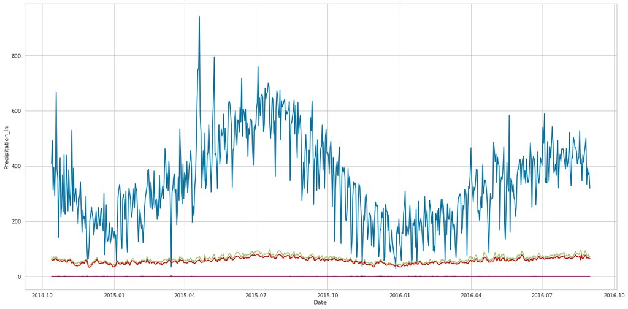

```python
#ploting number of rides with weather condictions
fig, ax = plt.subplots()
# the size of A4 paper
fig.set_size_inches(20.7, 10.27)
sns.lineplot(x="Date", y="count", data=weather, ax=ax)
sns.lineplot(x="Date", y="Max_Temperature_F", data=weather, ax=ax)
sns.lineplot(x="Date", y="Mean_Temperature_F", data=weather, ax=ax)
sns.lineplot(x="Date", y="Precipitation_In", data=weather, ax=ax)
```